# Energy Production Project Summary

Ghadi Dagher

2/24/2021

The original data can be found on **Our World in Data** github page available here. Also it is available as a csv file here.

This project consist of 5 main parts:

**1. Data Wrangling**  
**2. Data Visualization**  
**3. Time Series Analysis and Forecasting**  
**4. Exponential Smoothing Optimization**  
**5. Arima Optimization**

The packages needed for this project are

```r
library(tidyverse)
library(fpp2) #for time series analysis and forecasting
library(readxl)
```

# Data Wrangling

In the first part, data was imported from a csv file and transformed into a data frame. Then column names were changed and columns were transformed to numeric. The code below shows how it was done.

```r
filename="Energy-production-by-source-1900-2014.csv"
fullpath=file.path(getwd(), filename)
data1=read_csv(fullpath)%>%as.data.frame()
colnames(data1)=c("Entity","Year","Oil","Renewables")
data1=data1%>%mutate(Oil=as.numeric(Oil),Renewables=as.numeric(Renewables))
```

Now that we have the data frame we created a list and each element of that list is the data corresponding to one of the 8 regions or entities. This separation is helpful later for time series analysis.The code below shows how it was done.

```r
data1=data1%>%mutate(Entity=as.factor(Entity))
regions=levels(data1$Entity)
data.list=rep(NA,length(regions))%>%as.list()
for (i in 1:length(regions)) {
data.list[[i]]=data1%>%filter(Entity==regions[i])
}
```

The object regions is a character vector containing all the levels of the column Entity.

```r
regions=levels(data1$Entity)
regions
```

```
## [1] "Africa"                    "Asia and Oceania"
## [3] "Central and South America" "Eurasia"
## [5] "Europe"                    "Middle East"
## [7] "North America"             "World"
```

It is important to note that we should have transformed the data into a tidy format. Nonetheless, this was only required for data visualization in the second part. Other than that data.list was enough for our analysis.  
Also, there are a lot of missing values in this data.These NAs indicate that there were no oil or renewable energy production that year. Nothing was done to handle these NAs as they are automatically removed.

# Data Visualization

In this part, we created some plots in order to understand data. First, we plot the oil production as follows.

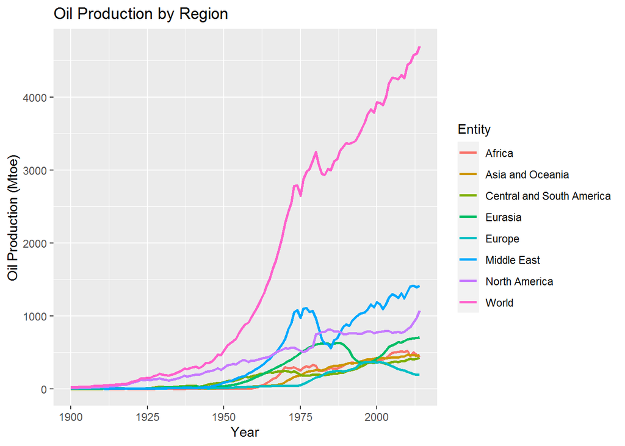

```r
p1=data1%>%select(Entity,Year,Oil)%>%group_by(Entity)%>%
  ggplot(aes(x=Year,y=Oil,col=Entity))+geom_line(size=1)+
  ggtitle("Oil Production by Region")+ylab("Oil Production (Mtoe)")
p1
```

Then we plot renewable energy production for all regions.

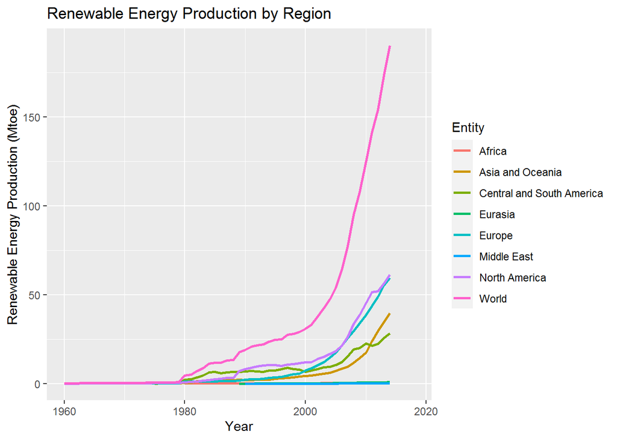

```r
p2=data1%>%select(Entity,Year,Renewables)%>%group_by(Entity)%>%
  ggplot(aes(x=Year,y=Renewables,col=Entity))+geom_line(size=1)+
  ggtitle("Renewable Energy Production by Region")+
  ylab("Renewable Energy Production (Mtoe)")+
  scale_x_continuous(limits = c(1960,2018))
p2
```

Finally we compare oil and renewable energy production for each region.Here, we have created a list of plots. Each element of the list corresponds to the plot of one region.

```r
regions=levels(data1$Entity)
p=rep(NA,length(regions))%>%as.list()
for (i in 1:length(regions)) {
  p[[i]]=data1%>%filter(Entity==regions[i])%>%
    gather(Type, Production,"Oil":"Renewables")%>%
    group_by(Type)%>%
    ggplot(aes(x=Year,y=Production,col=Type))+
    geom_line(size=1)+
    ggtitle(paste("Oil vs Renewable Energy In",regions[i],sep=" "))+
    ylab("Production (Mtoe)")
}
```

For example the plot for europe is given by

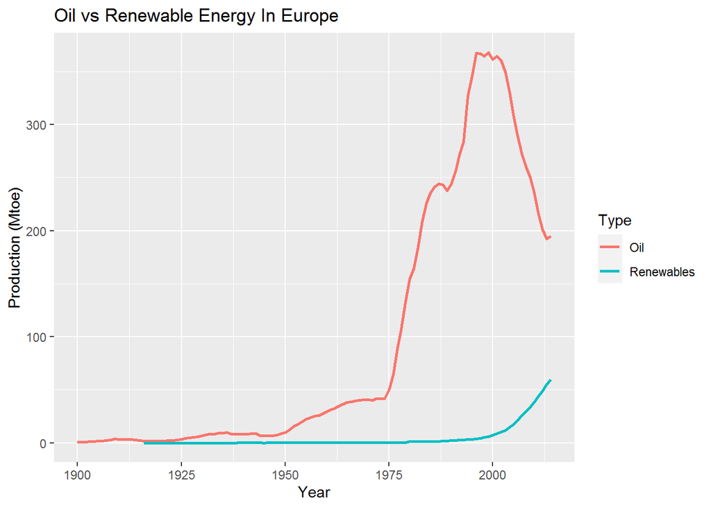

```r
p[[5]]
```

We can clearly see that oil production is much higher than renewable energy. This is the case for all other regions.

# Time Series Analysis and Forecasting

In this part we will work with oil production only. First, we need to divide our data into a training set and a test set. Since this is a time series data, we cannot divide at random. Thus, we will take the data of the last 20 years as a test set. All previous data will serve for training.  
Remember that we have 8 time series (one for each region). Thus, we need 8 different training and test sets. For this reason we will use lists as before.  
Note that before dividing data into train and test sets, we should transform the oil data from a numeric vector to a ts object. The ts object needed to use different functions in forecast package. We use the ts() function to create a ts object.

```r
firstyear=data1$Year[1]
lastyear=data1$Year[length(data1$Year)/8]

oil.ts=rep(NA,length(data.list))%>%as.list()
train.ts.2=rep(NA,length(data.list))%>%as.list()
test.ts.2=rep(NA,length(data.list))%>%as.list()

for (i in 1:length(data.list)) {
  oil.ts[[i]]=ts(data.list[[i]]$Oil, start=firstyear, end=lastyear, frequency=1)
  train.ts.2[[i]]=window(oil.ts[[i]],end=1994)
  test.ts.2[[i]]=window(oil.ts[[i]],start=1995)

}
```

For each region, we will forecast oil production using 5 methods which are

1.The mean forecast: the forecast of future values is the mean of the training data  
2.The naive forecast: the forecast of future data is equal to the last value in the training data  
3.The drift forecast: the forecast of future data is determined using a line created using the first and last point of the data  
4.The automatic exponential smoothing (ets) forecast: we let the ets() function in R choose the best ets model  
5.The automatic arima forecast: we let the auto.arima() function in R choose the best arima model

The first 3 methods are used as benchmarks (baseline). The ets and arima models should beat the benchmarks in order to be taken into consideration.

The choice of the arima model is a little bit more complicated and can be found in [**Forecasting: Principles and Practices**](https://otexts.com/fpp2/arima-estimation.html) chapter 8. Nonetheless, it also uses the AICc given by
$$AICc=-2log(L)+2(p+q+k+1)+\frac{2(p+q+k+1)(p+q+k+2)}{T-p-q-k-2}$$
where p and q are the autoregressive and moving average orders respectively.
The following code will allow us to create the 5 methods described above for every region.

```r
h2=20

mean.forecast.2=rep(NA,length(data.list))%>%as.list()
naive.forecast.2=rep(NA,length(data.list))%>%as.list()
drift.forecast.2=rep(NA,length(data.list))%>%as.list()
arima.forecast.2=rep(NA,length(data.list))%>%as.list()
ets.forecast.2=rep(NA,length(data.list))%>%as.list()


for (i in 1:length(data.list)) {
  mean.forecast.2[[i]]=meanf(train.ts.2[[i]], h=h2)
  naive.forecast.2[[i]]=rwf(train.ts.2[[i]], h=h2)
  drift.forecast.2[[i]]=rwf(train.ts.2[[i]], h=h2,drift = TRUE)
  ets.forecast.2[[i]]=ets(train.ts.2[[i]],restrict = FALSE)
  arima.forecast.2[[i]]=auto.arima(train.ts.2[[i]], seasonal=FALSE, stepwise=FALSE, approximation = FALSE)
}
```

We can also create list of the plots containing the forecasts as follows

```r
regions=levels(data1$Entity)
plots.forecast.2=rep(NA,length(data.list))%>%as.list()

for (i in 1:length(data.list)) {

  plots.forecast.2[[i]]=oil.ts[[i]]%>%autoplot(size=1)+
    autolayer(mean.forecast.2[[i]],series="Mean", PI=FALSE,size=1)+
    autolayer(naive.forecast.2[[i]],series="Naive", PI=FALSE,size=1)+
    autolayer(drift.forecast.2[[i]],series="Drift", PI=FALSE,size=1)+
    autolayer(ets.forecast.2[[i]]%>%forecast(h=h2,PI=FALSE),series="ETS",size=1)+
    autolayer(arima.forecast.2[[i]]%>%forecast(h=h2),series="Arima",PI=FALSE,size=1)+
    ggtitle(paste("Oil Production and Forecasts in",regions[i],sep=" "))+
    ylab("Production (Mtoe)")
}
```

For example, for the world data

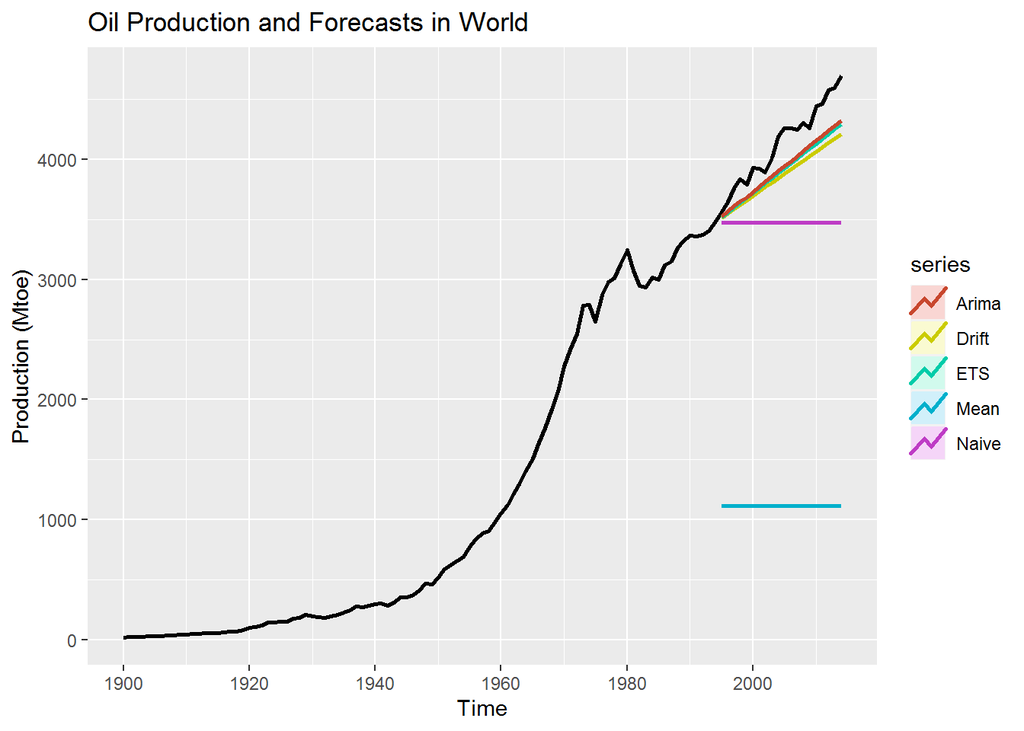

```r
plots.forecast.2[[8]]
```

Now it is important to see which model performed the best for each region. To do so, we will compare the test RMSE of the 5 methods. The winning method for each region will be printed on screen. We can do this as follows

```r
model.name=c("mean","naive","drift","ets","arima")
acc=rep(NA,5)

for (i in 1:length(data.list)) {
  acc1=mean.forecast.2[[i]]%>%accuracy(test.ts.2[[i]])
  acc2=naive.forecast.2[[i]]%>%accuracy(test.ts.2[[i]])
  acc3=drift.forecast.2[[i]]%>%accuracy(test.ts.2[[i]])
  acc4=ets.forecast.2[[i]]%>%forecast(h=h2,PI=FALSE)%>% accuracy(test.ts.2[[i]])
  acc5=arima.forecast.2[[i]]%>%forecast(h=h2)%>%accuracy(test.ts.2[[i]])
  index=c(acc1[4],acc2[4],acc3[4],acc4[4],acc5[4])%>%as.numeric()%>% which.min()
  print(paste(paste("Best model for",regions[i],sep = " "), model.name[index],sep = " is "))
}
```

```
## [1] "Best model for Africa is arima"
## [1] "Best model for Asia and Oceania is drift"
## [1] "Best model for Central and South America is arima"
## [1] "Best model for Eurasia is drift"
## [1] "Best model for Europe is naive"
## [1] "Best model for Middle East is drift"
## [1] "Best model for North America is drift"
## [1] "Best model for World is arima"
```

We can see that we obtained arima 3 times, drift 4 times and naive one time. Thus it appears that the baseline methods perform better than arima and ets.

# Exponential smoothing optimization

The **ets()** and **auto.arima()** functions are both automatic functions that choose the best model based on the AICc values. When working with automatic functions, we should always work with caution and verify if we have the best possible model. In this part, we will try to optimize the ets forecast for the world data only.

First, let’s take a look at the plot of the world oil energy production

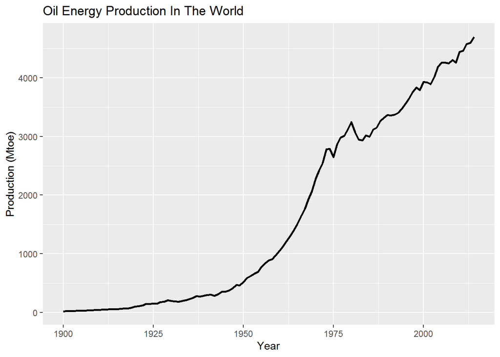

```r
data1%>%filter(Entity=="World")%>%
    select(Year,Oil)%>%
    ggplot(aes(x=Year,y=Oil))+
    geom_line(size=1)+
    ggtitle("Oil Energy Production In The World")+
    ylab("Production (Mtoe)")
```

If we look at the automatic ets model

```r
ets.forecast.2[[8]]
```

```
## ETS(M,A,N)
##
## Call:
##  ets(y = train.ts.2[[i]], restrict = FALSE)
##
##   Smoothing parameters:
##     alpha = 0.9999
##     beta  = 0.207
##
##   Initial states:
##     l = 17.909
##     b = 2.2282
##
##   sigma:  0.0562
##
##      AIC     AICc      BIC
## 1041.152 1041.826 1053.921
```

We see that the chosen model is a MAN model. The first letter is for the error which mean that the error here is multiplicative “M”. The second letter is for the trend which is an additive trend in our case. The last letter is for seasonality. Here the “N” indicates a “none” which means that there is no seasonality.  
In fact by looking at the oil production curve we see no seasonality thus the N part is very logical and expected. For the A part. We have 4 possibilities A, Ad (additive damped), M (multiplicative), or N (none). We know it’s not N because we have a trend. It’s not M because multiplicative trends are never a good option. Also it’s not Ad because the curve continue to rise (it’s not damped). So the A is also logical and expected. Finally for the M part we have 2 possibilities A or M. Both are possible. The algorithm chose M because the model gave lower AICc.

Thus if we want to optimize the model we should try all the logical combinations. According to the explication given above the only possible model to test is the AAN model.

We will create this model and compare the cross-validation RMSE and MAE. To perform a cross validation using the **forecast** package, we should create the following functions first.

```r
fets.1 <- function(x,h) {
  forecast(ets(x,model = "MAN"), h = h, PI=FALSE)
}

fets.2 <- function(x,h) {
  forecast(ets(x,model = "AAN"), h = h, PI=FALSE)
}
```

We create the second model as follows

```r
ets.world.AAN=ets(train.ts.2[[8]],model = "AAN")
```

The cross-validation is done as follows

```r
e1=tsCV(train.ts.2[[8]], fets.1, h=1) # Compute CV errors for MAN as e1
e2=tsCV(train.ts.2[[8]], fets.2, h=1) # Compute CV errors for AAN as e2
#the tsCV() function returns a residual and not an accuracy measure

#RMSE of each model
rmse.1=mean(e1^2, na.rm=TRUE)%>%sqrt()
rmse.2=mean(e2^2, na.rm=TRUE)%>%sqrt()

rmse.1
```

```
## [1] 57.28456
```

```r
rmse.2
```

```
## [1] 69.06671
```

```r
#Thus the CV RMSE is lower for the MAN model

#MAE of each model
mae.1=e1%>%abs()%>%mean(na.rm=TRUE)
mae.2=e2%>%abs()%>%mean(na.rm=TRUE)

mae.1
```

```
## [1] 30.51336
```

```r
mae.2
```

```
## [1] 33.50609
```

```r
#also the CV MAE is lower for the MAN model
#Thus the MAN model is the best ets model possible
```

We can see that CV-RMSE and CV-MAE for the MAN model are both lower than the AAN model. As a result, it is not possible to optimize any more.

Finally let’s calculate the test RMSE for the MAN model.

```r
test.RMSE=ets.forecast.2[[8]]%>%forecast(h=h2,PI=FALSE)%>% accuracy(test.ts.2[[8]])
test.RMSE[4]
```

```
## [1] 248.6922
```

# Arima optimization

In this part, we will try to optimize the arima forecast for the world data.  
If we look at the automatic model

```r
arima.forecast.2[[8]]
```

```
## Series: train.ts.2[[i]]
## ARIMA(5,2,0)
##
## Coefficients:
##           ar1      ar2      ar3      ar4      ar5
##       -0.5082  -0.5354  -0.2976  -0.1111  -0.3961
## s.e.   0.0947   0.1074   0.1169   0.1065   0.0923
##
## sigma^2 estimated as 2710:  log likelihood=-497.76
## AIC=1007.51   AICc=1008.49   BIC=1022.71
```

The automatic arima function gave an ARIMA(5,2,0) model. In this case d=2 and we have no constant thus long-term forecasts will follow a straight line ([ref](https://otexts.com/fpp2/non-seasonal-arima.html)).

In the case of arima we can’t analyze as we did with ets. However it is logical and expected not to obtain a seasonal part. Here to optimize we need to test different models by adding or subtracting 1 from each element thus we will test ARIMA(4,2,0), ARIMA(6,2,0) and ARIMA(5,2,1). Note that we will keep d=2 for stationarity.

We will create the models as follows

```r
arima.world.2=Arima(train.ts.2[[8]],order = c(4,2,0),seasonal = c(0,0,0) )
arima.world.3=Arima(train.ts.2[[8]],order = c(6,2,0),seasonal = c(0,0,0) )
arima.world.4=Arima(train.ts.2[[8]],order = c(5,2,1),seasonal = c(0,0,0) )
```

Cross-validation is done as before

```r
#The function tsCV requires that we write the functions like that
farima <- function(x, h,p,q) {
  forecast(Arima(x,order = c(p,2,q),seasonal = c(0,0,0)), h=h)
}

e1=tsCV(train.ts.2[[8]], farima, h=1,p=5,q=0) # Compute CV errors for ARIMA(5,2,0) as e1
e2=tsCV(train.ts.2[[8]], farima, h=1,p=4,q=0) # Compute CV errors for ARIMA(4,2,0) as e2
e3=tsCV(train.ts.2[[8]], farima, h=1,p=6,q=0) # Compute CV errors for ARIMA(6,2,0) as e3
e4=tsCV(train.ts.2[[8]], farima, h=1,p=5,q=1) # Compute CV errors for ARIMA(5,2,1) as e4

#RMSE of each model
rmse.1=mean(e1^2, na.rm=TRUE)%>%sqrt()
rmse.2=mean(e2^2, na.rm=TRUE)%>%sqrt()
rmse.3=mean(e3^2, na.rm=TRUE)%>%sqrt()
rmse.4=mean(e4^2, na.rm=TRUE)%>%sqrt()

rmse.1
```

```
## [1] 79.72128
```

```r
rmse.2
```

```
## [1] 72.10685
```

```r
rmse.3
```

```
## [1] 62.10222
```

```r
rmse.4
```

```
## [1] 65.97491
```

```r
#Thus the CV RMSE is the lowest for the third model which is ARIMA(6,2,0)

#MAE of each model
mae.1=e1%>%abs()%>%mean(na.rm=TRUE)
mae.2=e2%>%abs()%>%mean(na.rm=TRUE)
mae.3=e3%>%abs()%>%mean(na.rm=TRUE)
mae.4=e4%>%abs()%>%mean(na.rm=TRUE)

mae.1
```

```
## [1] 46.92801
```

```r
mae.2
```

```
## [1] 40.97342
```

```r
mae.3
```

```
## [1] 40.14339
```

```r
mae.4
```

```
## [1] 37.12127
```

```r
#The CV MAE is the lowest for the fourth model which is ARIMA(5,2,1)
```

The first model gave the worst results for both measures so we are sure that it isn’t the best arima model. However here each measure gave a different model. To make a decision we could either choose one the 2 either calculate a third measure We will calculate the MAPE.

```r
mape.3=(100*e3/train.ts.2[[8]])%>%abs()%>%mean(na.rm=TRUE)
mape.4=(100*e4/train.ts.2[[8]])%>%abs()%>%mean(na.rm=TRUE)

mape.3
```

```
## [1] 4.359353
```

```r
mape.4
```

```
## [1] 4.85844
```

```r
#Both models gave close results 4.36% and 4.86%
#However we will choose the third one since it has a lower MAPE and RMSE
```

Now, let’s calculate the test error for this model and for the initial one

```r
initial.model=arima.forecast.2[[8]]%>%forecast(h=20)%>%accuracy(test.ts.2[[8]])
initial.model[4]
```

```
## [1] 229.6736
```

```r
optimized.model=arima.world.3%>%forecast(h=20)%>%accuracy(test.ts.2[[8]])
optimized.model[4]
```

```
## [1] 202.7681
```